# Hemorrhoidectomy

2022-03-27

```
## # A tibble: 10 × 20
## # Groups:   id [1]
##       id treatment   age sex   n_package n_dep   eva bleed    secretion def_char
##    <dbl>     <dbl> <dbl> <chr>     <dbl> <dbl> <dbl> <chr>        <dbl> <chr>
##  1     1         3    45 F             2     1     8 drops            1 solid
##  2     1         3    45 F             2     1     7 drops            1 pasty
##  3     1         3    45 F             2     1     6 drops            1 pasty
##  4     1         3    45 F             2     1     6 no drops         1 pasty
##  5     1         3    45 F             2     0    NA no drops         1 <NA>
##  6     1         3    45 F             2     1     4 no drops         1 pasty
##  7     1         3    45 F             2     1     3 no drops         1 liquid
##  8     1         3    45 F             2     0    NA no drops         1 <NA>
##  9     1         3    45 F             2     1     3 no               1 pasty
## 10     1         3    45 F             2     1     3 no               1 pasty
## # … with 10 more variables: head <dbl>, dizz <dbl>, vomit <dbl>,
## #   constipa <dbl>, abpain <dbl>, swelling <dbl>, itch <dbl>, rash <dbl>,
## #   insomnia <dbl>, time <int>
```

## Summary statistics

### Sangrado

```
## # A tibble: 9 × 4
## # Groups:   treatment [3]
##   bleed    treatment     n  prop
##   <chr>        <dbl> <int> <dbl>
## 1 drops            1   233  0.46
## 2 drops            2   182  0.37
## 3 drops            3   125  0.3
## 4 no               1   107  0.21
## 5 no               2   247  0.5
## 6 no               3   148  0.36
## 7 no drops         1   165  0.33
## 8 no drops         2    62  0.13
## 9 no drops         3   143  0.34
```

El 50% del grupo 2 no sangró, la mayor proporcion de sangrado en gotas es del grupo 1 (46%).

### Sexo

```
## # A tibble: 6 × 4
## # Groups:   treatment [3]
##   sex   treatment     n  prop
##   <chr>     <dbl> <int> <dbl>
## 1 F             1   267  0.53
## 2 F             2   127  0.26
## 3 F             3   240  0.58
## 4 M             1   238  0.47
## 5 M             2   364  0.74
## 6 M             3   176  0.42
```

Se puede ver que los grupos están desbalanceados en cuanto a sexo, sobretodo el grupo 2.

### Secreciones

```
## # A tibble: 9 × 4
## # Groups:   treatment [3]
##   secretion treatment     n  prop
##       <dbl>     <dbl> <int> <dbl>
## 1         0         1    39  0.08
## 2         0         2    72  0.15
## 3         0         3    39  0.09
## 4         1         1   335  0.66
## 5         1         2   296  0.6
## 6         1         3   306  0.74
## 7         2         1   131  0.26
## 8         2         2   123  0.25
## 9         2         3    71  0.17
```

El grupo 2 muestra la mayor proporcion de 0 secreciones (15%)

### Numero de deposiciones

```
## # A tibble: 21 × 4
## # Groups:   treatment [3]
##    n_dep treatment     n  prop
##    <dbl>     <dbl> <int> <dbl>
##  1     0         1     2  0
##  2     0         2     2  0
##  3     0         3     3  0.01
##  4     1         1   213  0.42
##  5     1         2   263  0.54
##  6     1         3   252  0.61
##  7     2         1   195  0.39
##  8     2         2   126  0.26
##  9     2         3   102  0.25
## 10     3         1    67  0.13
## # … with 11 more rows
```

El número de deposiciones no es muy informativo por si solo, sirve como variable de control para el dolor. Es posible que mientras más defequen, más le duela. Sobretodo en los primeros días.

### Escala EVA

```
##    Min. 1st Qu.  Median    Mean 3rd Qu.    Max.    NA's
##   0.000   3.000   5.000   5.342   7.000  23.000     220
```

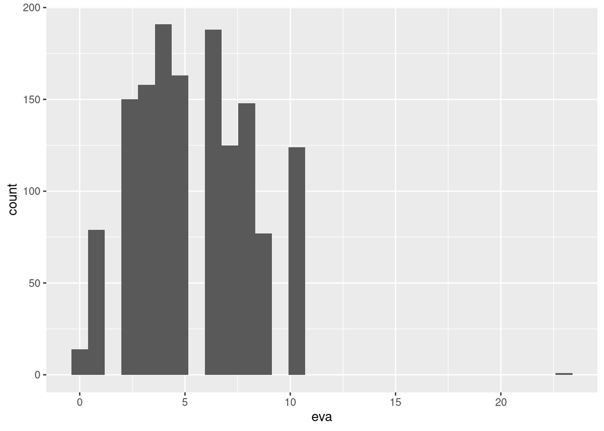

```
##
##   0   1   2   3   4   5   6   7   8   9  10  23
##  14  79 150 158 191 163 188 125 148  77 124   1
```

```
## # A tibble: 1 × 20
## # Groups:   id [1]
##      id treatment   age sex   n_package n_dep   eva bleed secretion def_char
##   <dbl>     <dbl> <dbl> <chr>     <dbl> <dbl> <dbl> <chr>     <dbl> <chr>
## 1    24         3    34 F             2     2    23 no            1 pasty
## # … with 10 more variables: head <dbl>, dizz <dbl>, vomit <dbl>,
## #   constipa <dbl>, abpain <dbl>, swelling <dbl>, itch <dbl>, rash <dbl>,
## #   insomnia <dbl>, time <int>
```

El sujeto 24, en el tiempo 12 tiene un registro de 23. **REVISAR** De momento vamos a dejar fuera esa observacion

## Gráfico

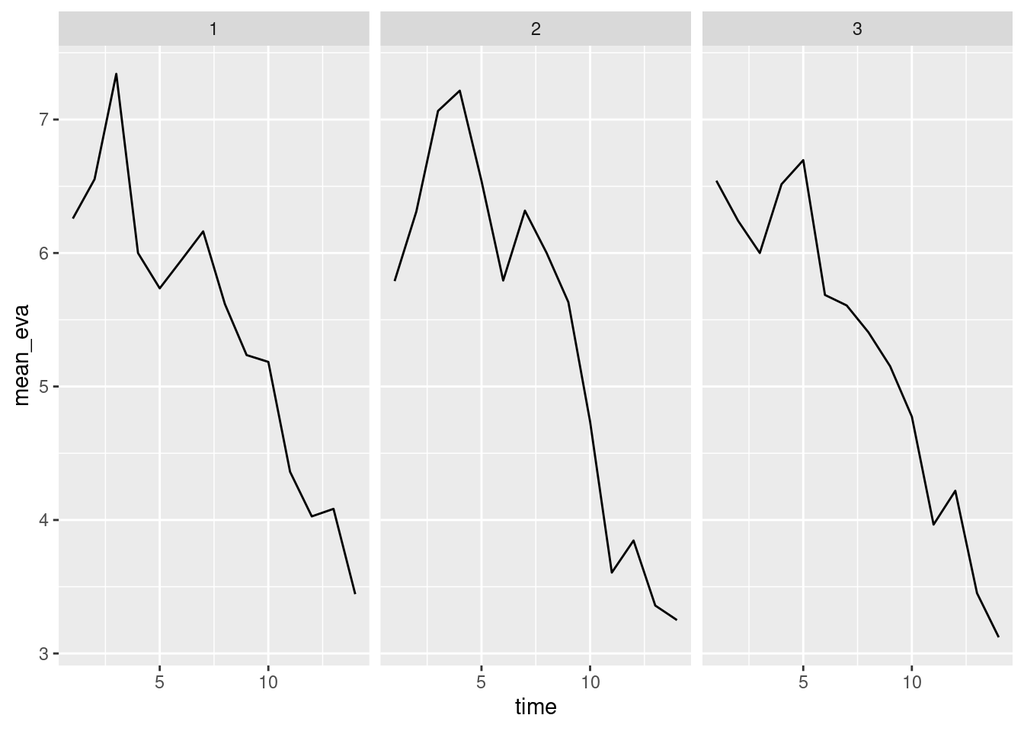

Los grupos tienen comportamiento similares, es necesario explorar un poco más.

```
## # A tibble: 42 × 5
##    treatment  time variable     n median
##        <dbl> <int> <chr>    <dbl>  <dbl>
##  1         1     1 eva         31    7
##  2         1     2 eva         38    6.5
##  3         1     3 eva         38    7
##  4         1     4 eva         38    6
##  5         1     5 eva         34    5
##  6         1     6 eva         38    6
##  7         1     7 eva         37    6
##  8         1     8 eva         34    5
##  9         1     9 eva         34    5
## 10         1    10 eva         38    5
## # … with 32 more rows
```

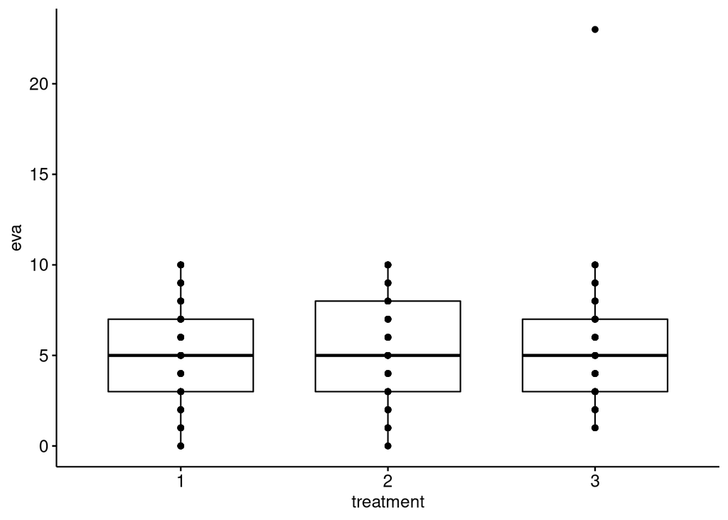

```
## # A tibble: 3 × 5
##   treatment variable     n  mean    sd
##       <dbl> <chr>    <dbl> <dbl> <dbl>
## 1         1 age        546  45    8.95
## 2         2 age        574  43.7 10.6
## 3         3 age        518  48.9 11.0
```

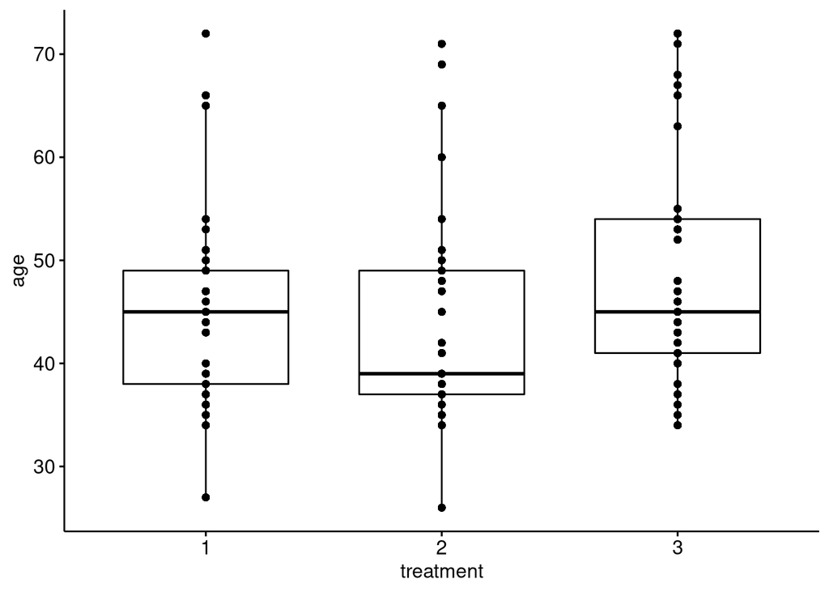

```
## # A tibble: 3 × 4
##   treatment variable statistic        p
##       <dbl> <chr>        <dbl>    <dbl>
## 1         1 age          0.920 1.93e-16
## 2         2 age          0.863 5.20e-22
## 3         3 age          0.898 4.79e-18
```

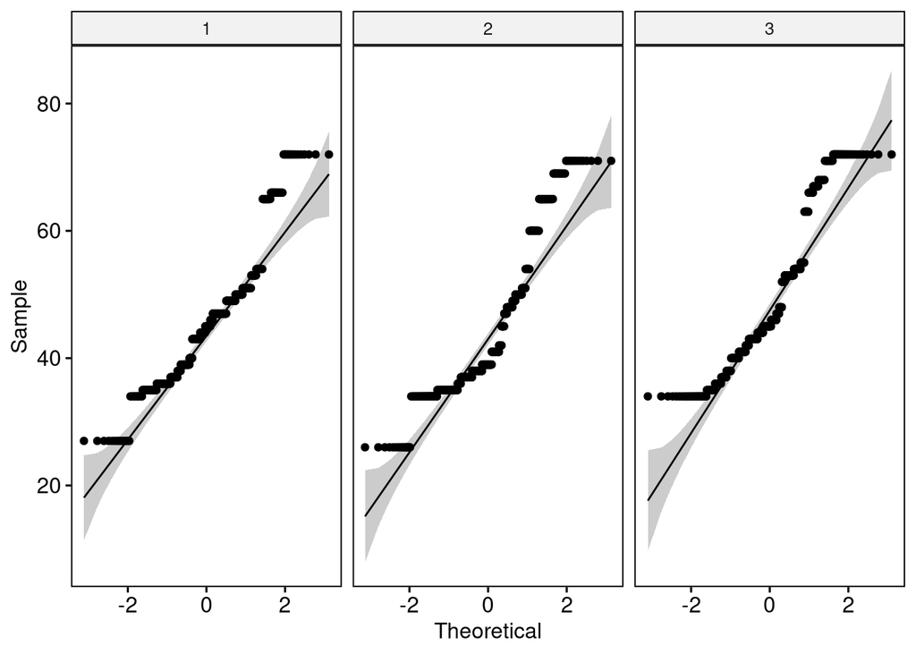

```
##                        Df Sum Sq Mean Sq F value Pr(>F)
## as.factor(treatment)    2   7902    3951   37.77 <2e-16 ***
## Residuals            1635 171041     105
## ---
## Signif. codes:  0 '***' 0.001 '**' 0.01 '*' 0.05 '.' 0.1 ' ' 1
```

Assumptions of spherecity and normality are not satisfied. Thus, we have to find non parametric methods to test the difference of baseline variables between groups. One alternative is to perform a Friedman test, but requires a compound symmetry sructure of the covariance matrix. This is extremely questionable for data in time courses.

Another approach is to use a nonparametric marginal model to perform a “non parametric anova for repeated measures”.

### Descriptives of side effects

```
## # A tibble: 6 × 4
## # Groups:   treatment [3]
##    head treatment     n  prop
##   <dbl>     <dbl> <int> <dbl>
## 1     0         1   524  0.96
## 2     0         2   562  0.98
## 3     0         3   487  0.94
## 4     1         1    22  0.04
## 5     1         2    12  0.02
## 6     1         3    31  0.06
```

El 4% del grupo 1 tuvo dolor de cabeza, el 2% del grupo 2 y el 6% del grupo 3.

```
## # A tibble: 6 × 4
## # Groups:   treatment [3]
##    dizz treatment     n  prop
##   <dbl>     <dbl> <int> <dbl>
## 1     0         1   506  0.93
## 2     0         2   559  0.97
## 3     0         3   458  0.88
## 4     1         1    40  0.07
## 5     1         2    15  0.03
## 6     1         3    60  0.12
```

El 7% del grupo 1 tuvo mareo, el 3% del grupo 2 y el 12% del grupo 3

```
## # A tibble: 6 × 4
## # Groups:   treatment [3]
##   vomit treatment     n  prop
##   <dbl>     <dbl> <int> <dbl>
## 1     0         1   535  0.98
## 2     0         2   573  1
## 3     0         3   504  0.97
## 4     1         1    11  0.02
## 5     1         2     1  0
## 6     1         3    14  0.03
```

El 2% del grupo 1 tuvo vomito, solo 1 persona tuvo vomito en el grupo 2 y el 3% del grupo 3.

```
## # A tibble: 6 × 4
## # Groups:   treatment [3]
##   constipa treatment     n  prop
##      <dbl>     <dbl> <int> <dbl>
## 1        0         1   506  0.93
## 2        0         2   490  0.85
## 3        0         3   439  0.85
## 4        1         1    40  0.07
## 5        1         2    84  0.15
## 6        1         3    79  0.15
```

El 7% del grupo 1 tuvo estreñimiento, el 15% del grupo 2 y el 15% del grupo 3.

```
## # A tibble: 6 × 4
## # Groups:   treatment [3]
##   abpain treatment     n  prop
##    <dbl>     <dbl> <int> <dbl>
## 1      0         1   492  0.9
## 2      0         2   560  0.98
## 3      0         3   477  0.92
## 4      1         1    54  0.1
## 5      1         2    14  0.02
## 6      1         3    41  0.08
```

El 10% del grupo 1 tuvo dolor abdominal, el 2% del grupo 2 y el 8% del grupo 3.

```
## # A tibble: 6 × 4
## # Groups:   treatment [3]
##   swelling treatment     n  prop
##      <dbl>     <dbl> <int> <dbl>
## 1        0         1   543  0.99
## 2        0         2   562  0.98
## 3        0         3   472  0.91
## 4        1         1     3  0.01
## 5        1         2    12  0.02
## 6        1         3    46  0.09
```

El 1% del grupo 1 tuvo hinchazón, el 2% del grupo 2 y el 9% del grupo 3.

```
## # A tibble: 6 × 4
## # Groups:   treatment [3]
##    itch treatment     n  prop
##   <dbl>     <dbl> <int> <dbl>
## 1     0         1   542  0.99
## 2     0         2   563  0.98
## 3     0         3   454  0.88
## 4     1         1     4  0.01
## 5     1         2    11  0.02
## 6     1         3    64  0.12
```

```
## # A tibble: 5 × 4
## # Groups:   treatment [3]
##    rash treatment     n  prop
##   <dbl>     <dbl> <int> <dbl>
## 1     0         1   544  1
## 2     0         2   574  1
## 3     0         3   492  0.95
## 4     1         1     2  0
## 5     1         3    26  0.05
```

El 5% del grupo 3 tuvo ronchas en la piel, 2 casos del grupo 1 y 0 del grupo 2.

```
## # A tibble: 6 × 4
## # Groups:   treatment [3]
##   insomnia treatment     n  prop
##      <dbl>     <dbl> <int> <dbl>
## 1        0         1   516  0.95
## 2        0         2   561  0.98
## 3        0         3   486  0.94
## 4        1         1    30  0.05
## 5        1         2    13  0.02
## 6        1         3    32  0.06
```

El 5% del grupo 1 tuvo insomnio, el 2% del grupo 2 y el 6% del grupo 3.

## Side effects

```
## # A tibble: 6 × 4
## # Groups:   treatment [3]
##   side_bin treatment     n  prop
##      <dbl>     <dbl> <int> <dbl>
## 1        0         1   411  0.75
## 2        0         2   464  0.81
## 3        0         3   331  0.64
## 4        1         1   135  0.25
## 5        1         2   110  0.19
## 6        1         3   187  0.36
```

El 25% del grupo 1 tuvo al menos 1 efecto secundario en un día, el 19% del grupo 2 y el 36% del grupo 3.

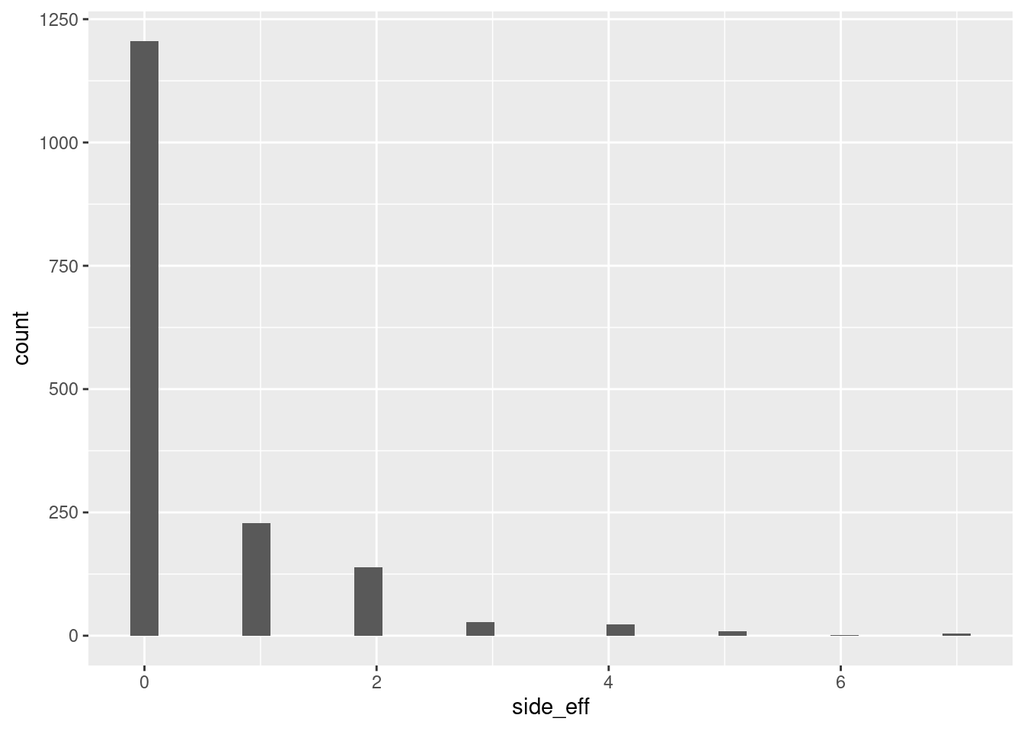

```r
ggplot(data_long, aes(x = side_eff)) +
  geom_histogram()
```